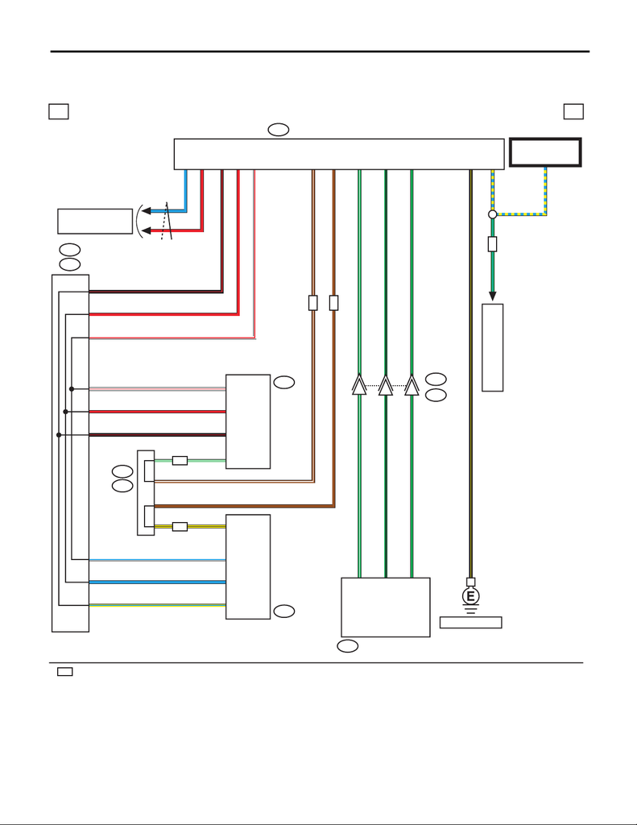

Headlight Beam Leveler System

WIRING SYSTEM

24.Headlight Beam Leveler System

A: WIRING DIAGRAM

WI-44449

F125

F126

R29

B150

B99

R3

F108A:

B361D:

7

9

8

B/R

LG

BR/W

BR

Y/B 6

B19 6

C11

C12

B18

R

W/R

11

10

12

A5

A1

A7

B/RD2

RD6

W/RD1

Y/L

L

W/L

11

10

12

A6

A2

A8

G/B

G/W

BR/W

BR

G

G/B

G/W

G

12

16

5

3

19

3

2

1

R

R

W/R

23

L24

17

10

B/R 11

B/YB/Y 2

1G/L 1

1

FB-35

F/B FUSE NO. 18

(IG)

F109B:

B360C:

CVT

EL

EL

EL

EL

FRONT

COMBINATION LIGHT LH

(HEADLIGHT BEAM LEVELER)

THROUGH

JOINT

CONNECTOR

REF. TO CAN

COMMUNICATION

SYSTEM [b]

FRONT

COMBINATION LIGHT RH

(HEADLIGHT BEAM LEVELER)

THROUGH JOINT

CONNECTOR

REAR VEHICLE HEIGHT

SENSOR

REF. TO GND [c]

AUTO HEADLIGHT BEAM LEVELER CM

EL

1

: ENGINE TYPE FA : G/L

ENGINE TYPE EJ : V

: EXCEPT FOR HALOGEN MODEL

REF. TO BACK-UP LIGHT

SYSTEM [1a]

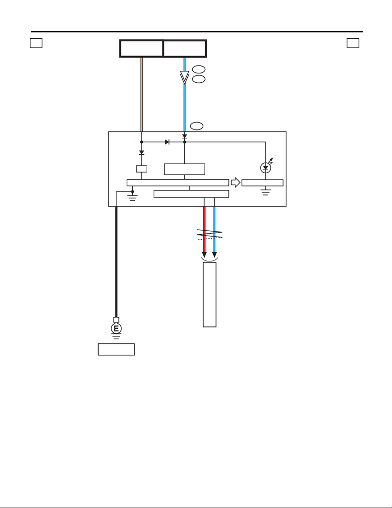

WI-251

Headlight Beam Leveler System

WIRING SYSTEM

WI-44450

b b

I/F

i10

i229

B551

3

38BB

R33

L32

W/L40

BR/W20 BR/W

W/LW/L

FB-12

F/B FUSE NO. 2

(IG)

FB-18

F/B FUSE NO. 7

(B)

COMBINATION

METER

REF. TO GND

[e]

AUTO HEADLIGHT

BEAM LEVELER

POWER SUPPLY

CIRCUIT

MICRO COMPUTER

CAN TRANSCEIVER & RECEIVER

DRIVE CIRCUIT

REF. TO CAN COMMUNICATION

SYSTEM [b]

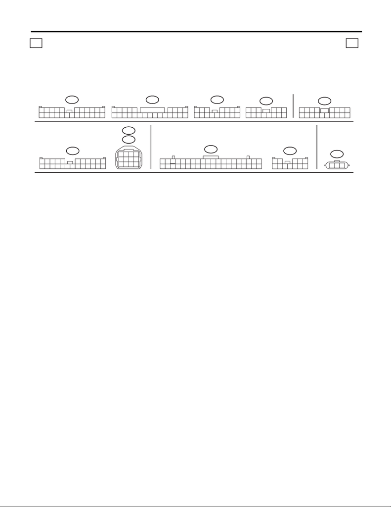

WI-252

Headlight Beam Leveler System

WIRING SYSTEM

F108

(GR)

1

9

23 8

10

4

567

17 18

A:

3412 89

10 11

12 13 14 15 16 17 18 19 20 21 22 23 24

567

F109

B:

WI-44451

c c

i10

11 12

9

10

7856341

2

15 1613 14 19

18

20

21 22 23 24 26

25

27 28 29 30 31 32 33 34 35 36 37 38 39 40

17

i229

12 345

6789

10 11 12

3412 89

10 11

12 13 14 15 16 17 18 19 20 21 22 23 24

567

B99

67893412 5

21 22 23 2417 18 19 201612 1310 11 14 15

B150

D:

(GR)

B361

123 456

789

10 11 12 13 14

F126

(GR)

F125

(GR)

1234

5678

9

10 11 12

(B)

R29

123

C:

(GR)

B360

123 4567

89

10 11 12 13 14 15 16

LIST OF CONNECTORS